# Encounter processing

LGCarlson

9/15/2020

## Encounter codes

*age:*

- 0 unknown
- 1 AHY
- 2 HY
- 3 Juvenile
- 4 Local
- 5 SY
- 6 ASY

*sex:*

- 0 unknown
- 4 M
- 5 F

_b_flyway / *r_flyway:*

- 2 Mississippi
- 3 Central
- 6 Canada

*b_region / r_region:* [codes here](https://www.pwrc.usgs.gov/BBL/MANUAL/reg.cfm#region) Canadian categories to keep: (US Flyways okay)

- 43 Northwest Territories
- 40 Nunavut
- 04 Alberta
- 79 Saskatchewan
- 45 Manitoba
- 68 Ontario

*b_month / r_month:*

- 1-12 or
- 82 Summer (06/21/YY thru 09/21/YY)
- 83 Spring (03/20/YY thru 06/20/YY)
- 92 Winter (12/21/YY-1 thru 03/19/YY)
- 93 Fall (09/22/YY thru 12/20/YY)
- 94 Hunting Season (09/01/YY thru 03/31/YY+1)
- 99 Unknown month and day of banding or encounter

*b_day / r_day:*

- 1-31 or
- 41 1st ten days in month
- 42 2nd ten days in month
- 43 3rd ten days in month
- 45 encountered during special hunting seasons
- 51-81 Encounter letter date or postmark date (plus 50)
- 99 Unknown day of banding or encounter

*how_obt:*

- 1 Shot

*hunt_season_surv:*

- number of hunting seasons survived (dbl)

*pres_cond:*

Categories to keep:

Code Bird condition Band status

- 03 DEAD UNKNOWN
- 04 DEAD LEFT ON BIRD
- 05 DEAD REMOVED

*status:*

- 2 transported
- 3 normal wild
- 4 hand reared
- 5 sick, injured, deformity
- 6,7,8 experimental, etc

*sp_num:*

- 1320 MALL

*ai_vai:*

- Categories to keep:
- Federal numbered metal band only.
- Captured by spotlighting.
- Misc. metal band (State, Provincial etc) with address or telephone number, plus Federal band.
- Miscellaneous band, Federal band, plus auxiliary marker(s).

## Setup

```r
theme_set(theme_light())

#set personalized plotting theme
LGCtheme <- theme_light() + theme(panel.background = element_blank(),
                panel.grid = element_blank(),
                axis.text = element_text(size = 13),
                axis.title = element_text(size = 14),
                legend.text = element_text(size = 13),
                legend.title = element_text(size = 14),
                strip.background = element_blank(),
                strip.text = element_text(size = 13, color = "black"))

gmri_qual_extended<-c("#003A54","#00608A","#5D96AF","#3F4B24","#6F7E4B","#97AA5C","#A8B212","#AF9700","#EACA00","#FFE961","#BB3F0E", "#EA4F12","#F4916B","#00736D", "#55A29E","#A0CDCB","#767676","#A7A7A7","#E2E2E2")
```

```r
provs_keep<-c(43,40,04,79,45,68)

provs_remove<-c(11,56,57,65,75,76,93)

ai_vai_vec<-c("Federal numbered metal band only.","Captured by spotlighting.", "Misc. metal band (State, Provincial etc) with address or telephone number, plus Federal band.","Miscellaneous band, Federal band, plus auxiliary marker(s).")

unknown_date_tib<-tibble(r_day=c(1:31,41,42,43,51:81,99),r_day_adj=c(1:31,5,15,25,1:31,15))

r_flyway_tib<-tibble(r_flyway=c(1,2,3,4,5,6,7),
                     r_flyway_name=c("Atlantic","Mississippi","Central","Pacific","Alaska","Canada","Mexico"))

r_region_codes<-read_csv(here::here("raw_data", "region_codes.csv")) %>%
  filter(!is.na(region_abbrev)) %>%
  dplyr::select(-region_name,-flyway_code) %>%
  dplyr::rename("r_region" = "region_code","r_region_abbrev" = "region_abbrev")
```

## Load data

```r
table(ca_enc$b_flyway);table(ca_enc$r_flyway)
```

```
##
##      6
## 314461
```

```
##
##      0      1      2      3      4      5      6      7
##    333  18258 137111  54258  43125     96  61256     24
```

```r
table(cl_enc$b_flyway);table(cl_enc$r_flyway)
```

```
##
##      3
## 136190
```

```
##
##     0     1     2     3     4     5     6     7
##   116   704 40870 76867  7661    38  9857    72
```

```r
table(ms_enc$b_flyway);table(ms_enc$r_flyway)
```

```
##
##      2
## 213994
```

```
##
##      0      1      2      3      4      5      6      7
##    266   7971 176619  13538    191     12  15391      5
```

```r
all_encs<-bind_rows(ca_enc, cl_enc, ms_enc) %>%
  left_join(r_flyway_tib, by = "r_flyway")
```

## Check data

```r
table(all_encs$how_obt) #should all be "1"
```

```
##
##      1
## 664645
```

```r
table(all_encs$r_year)
```

```
##
##  1961  1962  1963  1964  1965  1966  1967  1968  1969  1970  1971  1972  1973
##  2333  2665  5889  9493  7286 13152 13929 10817 12877 14093 12906 12680 10368
##  1974  1975  1976  1977  1978  1979  1980  1981  1982  1983  1984  1985  1986
##  8957  9173 10368 10372 10960 11711 11088 12564 12788 13600 13176 10240  9525
##  1987  1988  1989  1990  1991  1992  1993  1994  1995  1996  1997  1998  1999
##  9434  8600  8093  7971  8283  8993  8493  9398 12038 14895 15706 16382 18924
##  2000  2001  2002  2003  2004  2005  2006  2007  2008  2009  2010  2011  2012
## 24471 20379 16958 15985 15226 13839 12888 12802 13573 11283 10080  9034  8083
##  2013  2014  2015  2016  2017  2018  2019  2020
##  7240  8570  7996  8956  8939  8548  7693  1882
```

```r
table(all_encs$r_month)
```

```
##
##      1      2      3      4      5      6      7      8      9     10     11
## 116073   2017    749   1176    893    240    232    432  28497 162503 156846
##     12     82     83     92     93     94     99
## 166495      9     86    187   3046  23171   1993
```

```r
table(all_encs$r_day)
```

```
##
##     1     2     3     4     5     6     7     8     9    10    11    12    13
## 22507 21048 20311 19893 20149 18430 18200 18829 17973 21418 18164 18570 16861
##    14    15    16    17    18    19    20    21    22    23    24    25    26
## 18039 21864 18197 18529 18596 18206 22486 18299 18632 19832 19358 17898 21246
##    27    28    29    30    31    41    42    43    45    50    51    52    53
## 20805 21305 19280 18791  9981  3005  1712  2114   586     8   317   311   311
##    54    55    56    57    58    59    60    61    62    63    64    65    66
##   421   384   327   402   293   402   301   363   348   298   327   411   339
##    67    68    69    70    71    72    73    74    75    76    77    78    79
##   279   347   281   408   411   384   316   290   282   314   303   356   355
##    80    81    94    99
##   324   197     2 53119
```

## Processing code

*Modifications:*

- remove indv. where banding month is unknown
- remove indv. where recovery month is unknown
- remove indv. where banding day is unknown
- join unknown_date_tib by r_day, so that r_day_adj can be used when recovery month, but not recovery date, is known
- create a new column with banding date
- create a new column with recovery date
- limit years to 1961-2011
- keep only pre-season banded birds
- keep only normal, wild birds (status)
- keep only known sexes (4,5)
- keep only desired ai_vai’s
- remove birds that live unnaturally long (probably mistaken year, reported old band)

```r
final_encs<-all_encs %>%
  filter(b_month <= 12,
         r_month <= 12,
         b_day <= 31) %>%
  left_join(unknown_date_tib, by="r_day") %>%
  mutate(b_date = as.Date(paste(b_year,b_month,b_day, sep = "-"))) %>%
  mutate(r_date = as.Date(paste(r_year,r_month,r_day_adj, sep = "-"))) %>%
  filter(b_year >=1961 & b_year <=2011) %>%
  filter(b_month >=6 & b_month <=9) %>%
  filter(status == 3) %>%
  filter(sex == 4 | sex == 5) %>%
  filter(ai_vai %in% ai_vai_vec) %>%
  filter(hunt_season_surv < 20) %>%
  left_join(r_region_codes, by = c("b_region" = "r_region")) %>%
  dplyr::rename("b_region_abbrev" = "r_region_abbrev") %>%
  left_join(r_region_codes, by = "r_region") %>%
  dplyr::select(band,age,sex,sp_num,how_obt,pres_cond,status,hunt_season_surv,b_flyway,b_flyway_name,
                b_date,b_year,b_month,b_day,b_region,b_region_abbrev,b_dir,b_coord_precision,
                b_lat,b_long,gisb_lat,gisb_long,
                r_flyway,r_flyway_name,r_date,r_year,r_month,r_day,r_region,r_region_abbrev,r_dir,
                r_coordinate_precision,r_lat,r_long,gisr_lat,gisr_long,ai_vai,everything())
```

## Visualize data

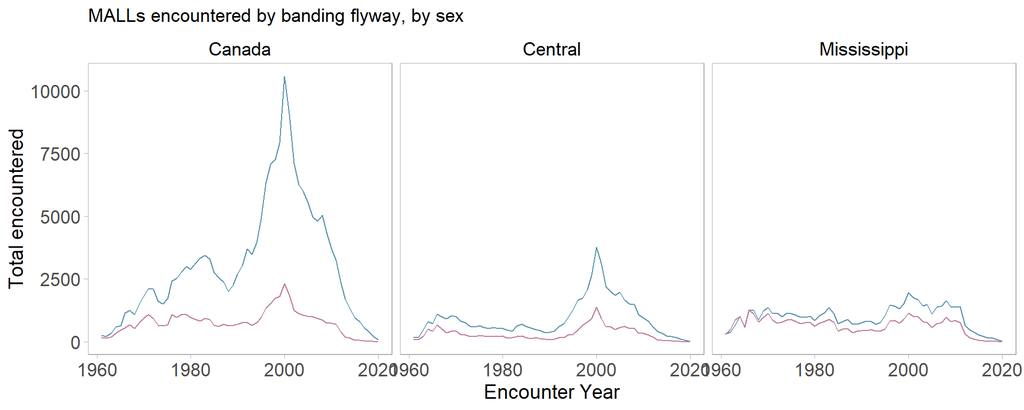

```r
final_encs %>%
  group_by(r_year, sex, b_flyway_name) %>%
  summarise(total_encountered = n()) %>%
  ggplot(aes(x=r_year, y=total_encountered, color=as.factor(sex))) + geom_line() +
  facet_wrap(~b_flyway_name, ncol=3) +
  scale_color_manual(values=c("#5D96AF","#C07F9C")) + LGCtheme + theme(legend.position = "none") +
  labs(x="Encounter Year", y="Total encountered",
       title="MALLs encountered by banding flyway, by sex")
```

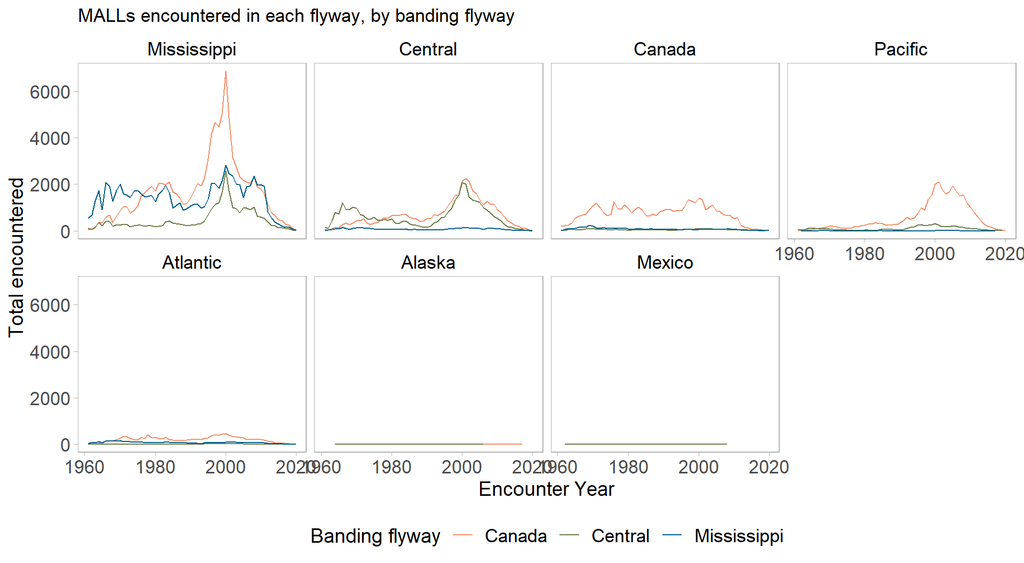

```r
final_encs %>%
  filter(r_flyway > 0 & is.na(r_flyway) == F) %>%
  group_by(r_year, b_flyway_name, r_flyway_name) %>%
  summarise(total_encountered = n()) %>%
  ggplot(aes(x=r_year, y=total_encountered, color=b_flyway_name)) + geom_line() +
  facet_wrap(~forcats::fct_reorder(r_flyway_name,total_encountered, .fun = sum, .desc = T), ncol=4) +
  scale_color_manual(values=c(gmri_qual_extended[13],gmri_qual_extended[5],gmri_qual_extended[2])) +
  LGCtheme + theme(legend.position = "bottom") +
  labs(x="Encounter Year", y="Total encountered", color="Banding flyway",
       title="MALLs encountered in each flyway, by banding flyway")
```

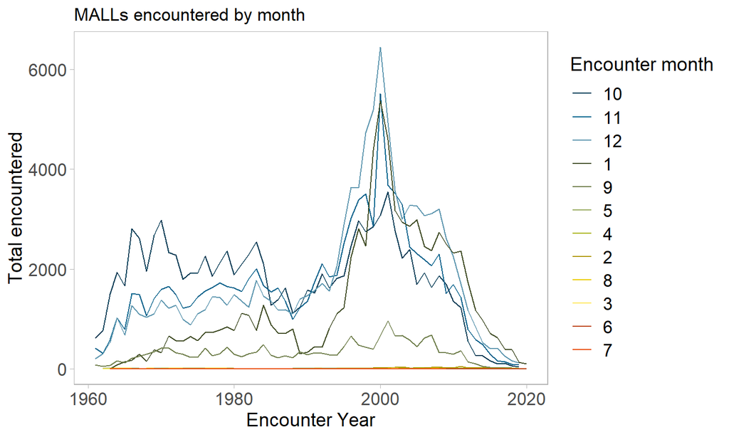

```r
final_encs %>%
  mutate(r_month = as.factor(r_month)) %>%
  group_by(r_year, r_month) %>%
  summarise(total_encountered = n()) %>%
  ggplot(aes(x=r_year, y=total_encountered, color=forcats::fct_reorder(r_month, total_encountered, .desc = T))) +
  geom_line() + scale_color_manual(values = gmri_qual_extended) + LGCtheme +
  labs(x="Encounter Year", y="Total encountered",
       title="MALLs encountered by month", color="Encounter month")
```

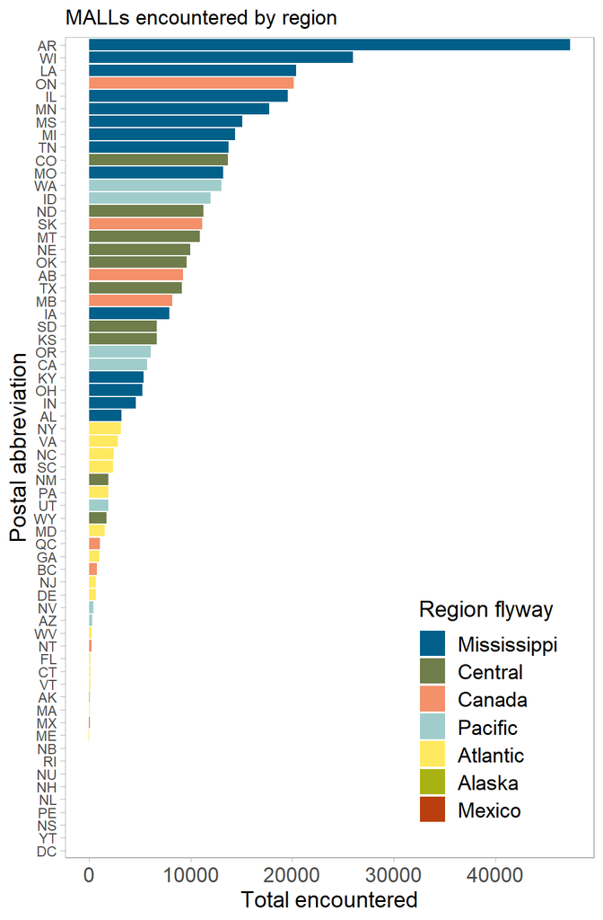

```r
final_encs %>%
  group_by(r_region_abbrev, r_flyway_name) %>%
  summarise(total_encountered = n()) %>%
  filter(!is.na(r_region_abbrev),
         r_region_abbrev != "Unknown") %>%
  ggplot(aes(x=forcats::fct_reorder(r_region_abbrev,total_encountered,.fun = sum, .desc = F),
          y=total_encountered, fill=forcats::fct_reorder(r_flyway_name,total_encountered,.fun = sum, .desc = T))) +
  geom_bar(stat = "identity") + coord_flip() +
  scale_fill_manual(values=c(gmri_qual_extended[2],gmri_qual_extended[5],gmri_qual_extended[13],
                    gmri_qual_extended[16],gmri_qual_extended[10],gmri_qual_extended[7],gmri_qual_extended[11])) +
  LGCtheme + theme(axis.text.y = element_text(size=9, angle=0)) +
  labs(x="Postal abbreviation",y="Total encountered", title="MALLs encountered by region",fill="Region flyway") +
  theme(legend.position = c(0.8,0.18))
```

## Spatial visualization

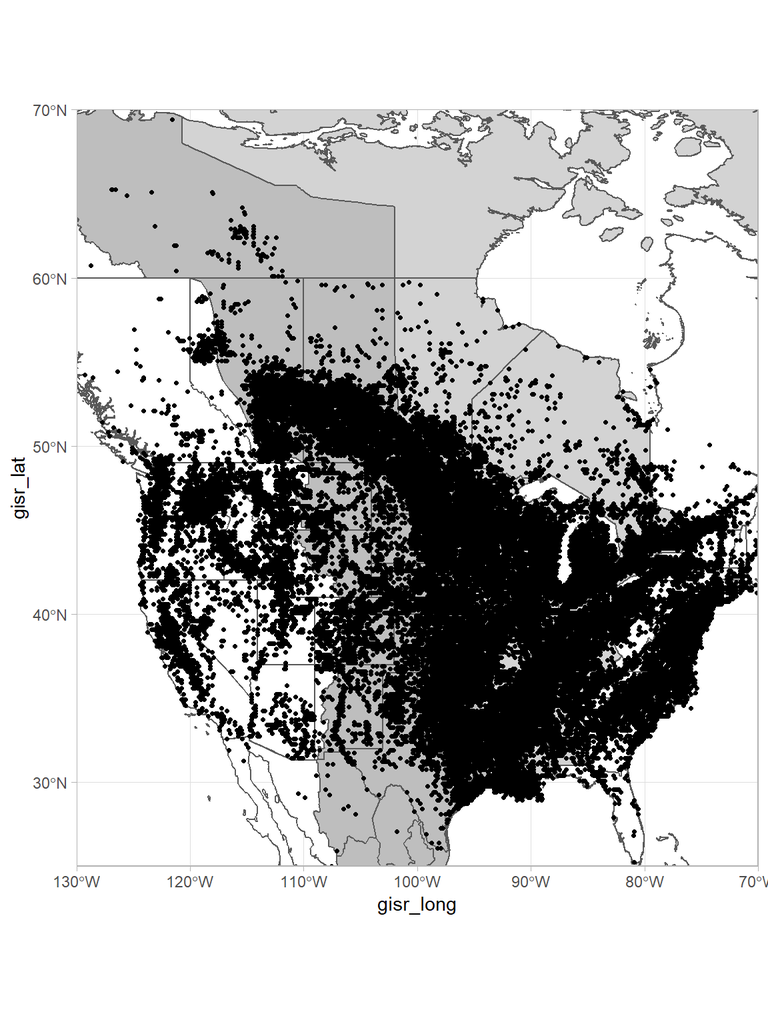

```r
ggplot(data = world) + geom_sf(fill="white") +
  geom_sf(data=states, fill=NA) +
  geom_sf(data=cent_flyway, fill="grey") +
  geom_sf(data=miss_flyway, fill="lightgrey") +
  geom_point(data=final_encs, aes(x=gisr_long, y=gisr_lat),size=0.85) +
    coord_sf(xlim = c(-130, -70), ylim = c(25, 70), expand = FALSE)
```

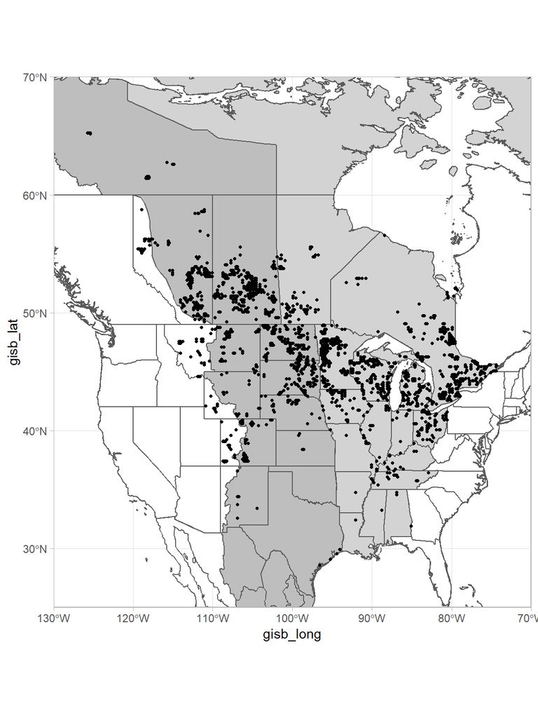

```r
ggplot(data = world) + geom_sf(fill="white") +
  geom_sf(data=states, fill=NA) +
  geom_sf(data=cent_flyway, fill="grey") +
  geom_sf(data=miss_flyway, fill="lightgrey") +
  geom_point(data=final_encs, aes(x=gisb_long, y=gisb_lat),size=0.85) +
    coord_sf(xlim = c(-130, -70), ylim = c(25, 70), expand = FALSE)
```

## Save datafile

```r
## write_csv(final_encs, here::here("proc_data","encounter_data.csv"))
```